# Health and Economic Consequences of Storms: 1950 - 2011

Charles Brown

Wednesday, March 18, 2015

### Synopsis

This report explores the NOAA Strom Database and shows the types of Events that are most harmful to population health and that cause the most property and crop damage.

### Data Processing

```r
strUrl <-"https://d396qusza40orc.cloudfront.net/repdata%2Fdata%2FStormData.csv.bz2"
strFilename <-"stormdata.bz2"
strDataDir <-""
```

- Download the compressed data file: https://d396qusza40orc.cloudfront.net/repdata%2Fdata%2FStormData.csv.bz2.

```r
strPathFilename <-file.path(getwd(), strDataDir, strFilename, fsep = "/")
strPathFilename <-sub(pattern = "/{2,}", replacement = "/", x = strPathFilename)
if (!file.exists(strPathFilename))
{
    download.file(url = strUrl, destfile = strPathFilename, mode = "wb")
}
```

- The compressed data file, stormdata.bz2, is very large: 46.9 Megabytes.
  - Read just the required variables into the data frame.
  - Cache the read to disk: `{r, ReadDataIntoDataFrame, cache=TRUE}`.

```r
df <-read.csv(file = strPathFilename, stringsAsFactors = FALSE,
              colClasses = c(rep("NULL",7),"character",rep("NULL",14),
                             rep("numeric",3),"character","numeric","character",
                             rep("NULL",9)))
summary(df)
```

```
##     EVTYPE            FATALITIES          INJURIES
##  Length:902297      Min.   :  0.0000   Min.   :   0.0000
##  Class :character   1st Qu.:  0.0000   1st Qu.:   0.0000
##  Mode  :character   Median :  0.0000   Median :   0.0000
##                     Mean   :  0.0168   Mean   :   0.1557
##                     3rd Qu.:  0.0000   3rd Qu.:   0.0000
##                     Max.   :583.0000   Max.   :1700.0000
##     PROPDMG         PROPDMGEXP           CROPDMG         CROPDMGEXP
##  Min.   :   0.00   Length:902297      Min.   :  0.000   Length:902297
##  1st Qu.:   0.00   Class :character   1st Qu.:  0.000   Class :character
##  Median :   0.00   Mode  :character   Median :  0.000   Mode  :character
##  Mean   :  12.06                      Mean   :  1.527
##  3rd Qu.:   0.50                      3rd Qu.:  0.000
##  Max.   :5000.00                      Max.   :990.000
```

- Calculate a new Event Group variable `(df$EVTGROUP)` to summarize the 985 Event Types.

```r
df$EVTGROUP <-NA
#
df[grep("^astro|^blow-out tide|^high tides",df$EVTYPE,ignore.case = TRUE),
     "EVTGROUP"] <-"Tides"
df[grep("^aval",df$EVTYPE, ignore.case = TRUE),
     "EVTGROUP"] <-"Avalanche"
df[grep("^blizz",df$EVTYPE, ignore.case = TRUE),
     "EVTGROUP"] <-"Blizzard"
df[grep("^coastal flood",df$EVTYPE, ignore.case = TRUE),
     "EVTGROUP"] <-"Coastal Flood"
df[grep("wind chill",df$EVTYPE, ignore.case = TRUE),
     "EVTGROUP"] <-"Wind Chill"
df[grep("debris flow",df$EVTYPE, ignore.case = TRUE),
     "EVTGROUP"] <-"Debris Flow"
df[grep("dense fog",df$EVTYPE, ignore.case = TRUE),
     "EVTGROUP"] <-"Dense Fog"
df[grep("smoke",df$EVTYPE, ignore.case = TRUE),
     "EVTGROUP"] <-"Dense Smoke"
df[grep("drought",df$EVTYPE, ignore.case = TRUE),
     "EVTGROUP"] <-"Drought"
df[grep("dust devil",df$EVTYPE, ignore.case = TRUE),
     "EVTGROUP"] <-"Dust Devil"
df[grep("^dust storm",df$EVTYPE, ignore.case = TRUE),
     "EVTGROUP"] <-"Dust Storm"
df[grep("^excessive heat|record/excessive heat",df$EVTYPE, ignore.case = TRUE),
     "EVTGROUP"] <-"Excessive Heat"
df[grep("extreme cold",df$EVTYPE, ignore.case = TRUE),
     "EVTGROUP"] <-"Extreme Cold/Wind Chill"
df[grep("^flood|flooding$",df$EVTYPE, ignore.case = TRUE),
     "EVTGROUP"] <-"Flood"
df[grep("^flash flood",df$EVTYPE, ignore.case = TRUE),
     "EVTGROUP"] <-"Flash Flood"
df[grep("frost",df$EVTYPE, ignore.case = TRUE),
     "EVTGROUP"] <-"Forst/Freeze"
df[grep("funnel",df$EVTYPE, ignore.case = TRUE),
     "EVTGROUP"] <-"Funnel Cloud"
df[grep("freezing fog",df$EVTYPE, ignore.case = TRUE),
     "EVTGROUP"] <-"Freezing Fog"
df[grep("hail",df$EVTYPE, ignore.case = TRUE),
     "EVTGROUP"] <-"Hail"
df[grep("^excessive heat|^extreme heat|^record heat", df$EVTYPE, ignore.case = TRUE),
     "EVTGROUP"] <-"Heat"
df[grep("^heat|excessive heat$", df$EVTYPE, ignore.case = TRUE),
     "EVTGROUP"] <-"Heat"
df[grep("^heavy rain",df$EVTYPE, ignore.case = TRUE),
     "EVTGROUP"] <-"Heavy Rain"
df[grep("^heavy snow|snow and heavy snow|snow/heavy snow",df$EVTYPE, ignore.case = TRUE),
     "EVTGROUP"] <-"Heavy Snow"
df[grep("^high surf",df$EVTYPE, ignore.case = TRUE),
     "EVTGROUP"] <-"High Surf"
df[grep("^high wind",df$EVTYPE, ignore.case = TRUE),
     "EVTGROUP"] <-"High Wind"
df[grep("^hurricane|^typhoon",df$EVTYPE, ignore.case = TRUE),
     "EVTGROUP"] <-"Hurricane Typhoon"
df[grep("^ice storm|glaze/ice storm|sleet/ice storm", df$EVTYPE, ignore.case = TRUE),
     "EVTGROUP"] <-"Ice Storm"
df[grep("snow and ice storm|snow/ice storm", df$EVTYPE, ignore.case = TRUE),
     "EVTGROUP"] <-"Ice Storm"
df[grep("lake-effect snow",df$EVTYPE, ignore.case = TRUE),
     "EVTGROUP"] <-"Lake-Effect Snow"
df[grep("lakeshore flood",df$EVTYPE, ignore.case = TRUE),
     "EVTGROUP"] <-"Lakeshore Flood"
df[grep("^lightning",df$EVTYPE, ignore.case = TRUE),
     "EVTGROUP"] <-"Lightning"
df[grep("marine hail",df$EVTYPE, ignore.case = TRUE),
     "EVTGROUP"] <-"Marine Hail"
df[grep("marine high wind",df$EVTYPE, ignore.case = TRUE),
     "EVTGROUP"] <-"Marine High Wind"
df[grep("marine strong wind",df$EVTYPE, ignore.case = TRUE),
     "EVTGROUP"] <-"Marine Strong Wind"
df[grep("marine thunderstorm wind",df$EVTYPE, ignore.case = TRUE),
     "EVTGROUP"] <-"Marine Thunderstorm Wind"
df[grep("rip current",df$EVTYPE, ignore.case = TRUE),
     "EVTGROUP"] <-"Rip Current"
df[grep("seiche",df$EVTYPE, ignore.case = TRUE),
     "EVTGROUP"] <-"Seiche"
df[grep("sleet|^freezing drizzle|^freezing rain",df$EVTYPE, ignore.case = TRUE),
     "EVTGROUP"] <-"Sleet"
df[grep("storm surge",df$EVTYPE, ignore.case = TRUE),
     "EVTGROUP"] <-"Storm Surge"
df[grep("^strong wind",df$EVTYPE, ignore.case = TRUE),
     "EVTGROUP"] <-"Strong Wind"
df[grep("gusty thunderstorm wind|^severe thunderstorm wind",df$EVTYPE, ignore.case = TRUE),
     "EVTGROUP"] <-"Thunderstorm Wind"
df[grep("^thunderstorm wind",df$EVTYPE, ignore.case = TRUE),
     "EVTGROUP"] <-"Thunderstorm Wind"
df[grep("tornado",df$EVTYPE, ignore.case = TRUE),
     "EVTGROUP"] <-"Tornado"
df[grep("tropical depression",df$EVTYPE, ignore.case = TRUE),
     "EVTGROUP"] <-"Tropical Depression"
df[grep("tropical storm",df$EVTYPE, ignore.case = TRUE),
     "EVTGROUP"] <-"Tropical Storm"
df[grep("tsunami",df$EVTYPE, ignore.case = TRUE),
     "EVTGROUP"] <-"Tsunami"
df[grep("volcanic",df$EVTYPE, ignore.case = TRUE),
     "EVTGROUP"] <-"Volcanic Ash"
df[grep("^waterspout",df$EVTYPE, ignore.case = TRUE),
     "EVTGROUP"] <-"Waterspout"
df[grep("wildfire",df$EVTYPE, ignore.case = TRUE),
     "EVTGROUP"] <-"Wildfire"
df[grep("^winter storm",df$EVTYPE, ignore.case = TRUE),
     "EVTGROUP"] <-"WinterStorm"
df[grep("winter weather",df$EVTYPE, ignore.case = TRUE),
     "EVTGROUP"] <-"Winter Weather"
```

- Calculate new Damage Amount variables `(df$PROPDMGAMT & df$CROPDMGAMT)` for each Event Type.

```r
df$PROPDMGAMT <- NA
#
df[grep("[0-9]", df$PROPDMGEXP), "PROPDMGAMT"] <- (10^as.numeric(df[grep("[0-9]",
    df$PROPDMGEXP, ), "PROPDMGEXP"])) * df[grep("[0-9]", df$PROPDMGEXP, ), "PROPDMG"]
df[grep("B", df$PROPDMGEXP, ignore.case = TRUE), "PROPDMGAMT"] <- df[grep("B",
    df$PROPDMGEXP, ignore.case = TRUE), "PROPDMG"] * 1e+09
df[grep("M", df$PROPDMGEXP, ignore.case = TRUE), "PROPDMGAMT"] <- df[grep("M",
    df$PROPDMGEXP, ignore.case = TRUE), "PROPDMG"] * 1e+06
df[grep("K", df$PROPDMGEXP, ignore.case = TRUE), "PROPDMGAMT"] <- df[grep("K",
    df$PROPDMGEXP, ignore.case = TRUE), "PROPDMG"] * 1000
df[grep("H", df$PROPDMGEXP, ignore.case = TRUE), "PROPDMGAMT"] <- df[grep("H",
    df$PROPDMGEXP, ignore.case = TRUE), "PROPDMG"] * 100
#
df$CROPDMGAMT <- NA
#
df[grep("[0-9]", df$CROPDMGEXP), "CROPDMGAMT"] <- (10^as.numeric(df[grep("[0-9]",
    df$CROPDMGEXP, ), "CROPDMGEXP"])) * df[grep("[0-9]", df$CROPDMGEXP, ), "CROPDMG"]
df[grep("B", df$CROPDMGEXP, ignore.case = TRUE), "CROPDMGAMT"] <- df[grep("B",
    df$CROPDMGEXP, ignore.case = TRUE), "CROPDMG"] * 1e+09
df[grep("M", df$CROPDMGEXP, ignore.case = TRUE), "CROPDMGAMT"] <- df[grep("M",
    df$CROPDMGEXP, ignore.case = TRUE), "CROPDMG"] * 1e+06
df[grep("K", df$CROPDMGEXP, ignore.case = TRUE), "CROPDMGAMT"] <- df[grep("K",
    df$CROPDMGEXP, ignore.case = TRUE), "CROPDMG"] * 1000
df[grep("H", df$CROPDMGEXP, ignore.case = TRUE), "CROPDMGAMT"] <- df[grep("H",
    df$CROPDMGEXP, ignore.case = TRUE), "CROPDMG"] * 100
```

- Calculate new Total Vectors for Fatalities, Injuries, Property Damage and Crop Damage by the Event Group `(df$EVTGROUP)`.

```r
Fatalities <-tapply(X = df$FATALITIES, INDEX = df$EVTGROUP, FUN = sum, na.rm = TRUE)
Injuries <-tapply(X = df$INJURIES, INDEX = df$EVTGROUP, FUN = sum, na.rm = TRUE)
PropDmgAmt <-tapply(X = df$PROPDMGAMT, INDEX = df$EVTGROUP, FUN = sum, na.rm = TRUE)
CropDmgAmt <-tapply(X = df$CROPDMGAMT, INDEX = df$EVTGROUP, FUN = sum, na.rm = TRUE)
```

### Results

- Rank Event Groups by the number of Population Fatalities.

```r
(Fatalities <-sort(x = Fatalities, decreasing = TRUE))
```

```
##                  Tornado                     Heat              Flash Flood
##                     5658                     3138                     1018
##                Lightning              Rip Current                    Flood
##                      817                      577                      501
##                High Wind  Extreme Cold/Wind Chill                Avalanche
##                      293                      287                      225
##              WinterStorm        Thunderstorm Wind        Hurricane Typhoon
##                      217                      199                      135
##               Heavy Snow              Strong Wind                High Surf
##                      129                      111                      104
##                 Blizzard               Heavy Rain               Wind Chill
##                      101                       98                       95
##                Ice Storm                 Wildfire           Tropical Storm
##                       89                       75                       66
##           Winter Weather                  Tsunami              Storm Surge
##                       61                       33                       24
##               Dust Storm                     Hail                Dense Fog
##                       22                       20                       18
##       Marine Strong Wind                    Sleet Marine Thunderstorm Wind
##                       14                       12                       10
##               Waterspout            Coastal Flood               Dust Devil
##                        6                        3                        2
##             Forst/Freeze         Marine High Wind              Dense Smoke
##                        1                        1                        0
##                  Drought             Freezing Fog             Funnel Cloud
##                        0                        0                        0
##         Lake-Effect Snow          Lakeshore Flood              Marine Hail
##                        0                        0                        0
##                   Seiche                    Tides      Tropical Depression
##                        0                        0                        0
##             Volcanic Ash
##                        0
```

- Rank the Event Groups by the number of Population Injuries.

```r
(Injuries <-sort(x = Injuries, decreasing = TRUE))
```

```
##                  Tornado                     Heat                    Flood
##                    91364                     9224                     6808
##                Lightning        Thunderstorm Wind                Ice Storm
##                     5232                     2402                     1992
##              Flash Flood                High Wind                     Hail
##                     1785                     1471                     1466
##              WinterStorm        Hurricane Typhoon               Heavy Snow
##                     1353                     1333                     1034
##                 Wildfire                 Blizzard           Winter Weather
##                      911                      805                      538
##              Rip Current               Dust Storm           Tropical Storm
##                      529                      440                      383
##                Dense Fog              Strong Wind  Extreme Cold/Wind Chill
##                      342                      301                      255
##               Heavy Rain                Avalanche                High Surf
##                      255                      170                      156
##                  Tsunami               Waterspout               Dust Devil
##                      129                       72                       43
##              Storm Surge                    Sleet Marine Thunderstorm Wind
##                       43                       38                       26
##       Marine Strong Wind               Wind Chill            Coastal Flood
##                       22                       12                        7
##                  Drought             Forst/Freeze             Funnel Cloud
##                        4                        3                        3
##         Marine High Wind              Dense Smoke             Freezing Fog
##                        1                        0                        0
##         Lake-Effect Snow          Lakeshore Flood              Marine Hail
##                        0                        0                        0
##                   Seiche                    Tides      Tropical Depression
##                        0                        0                        0
##             Volcanic Ash
##                        0
```

- Plot the Top 3 Event Groups by Fatalities and Injuries.

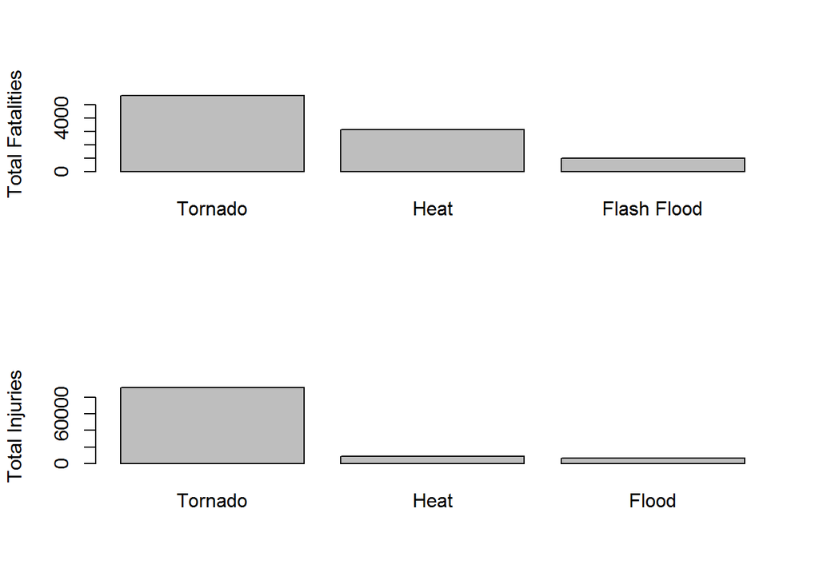

```r
par(mfrow = c(2,1))
barplot(Fatalities[1:3], ylab = "Total Fatalities")
barplot(Injuries[1:3], ylab = "Total Injuries")
```

- Rank the Event Groups by the amount of Property & Crop Damage.

```r
(PropDmgAmt <-sort(x = PropDmgAmt, decreasing = TRUE))
```

```
##                    Flood        Hurricane Typhoon                  Tornado
##             145223640907              85356410010              58552151864
##              Storm Surge              Flash Flood                     Hail
##              47964724000              17414680872              16021900956
##           Tropical Storm              WinterStorm                High Wind
##               7714390550               6748997251               6003352990
##        Thunderstorm Wind                 Wildfire                Ice Storm
##               5431305978               4865614000               3945527860
##               Heavy Rain                  Drought               Heavy Snow
##               3230998140               1046106000                953697140
##                Lightning                 Blizzard            Coastal Flood
##                935452427                659713950                279600560
##              Strong Wind                  Tsunami                High Surf
##                177674240                144062000                 89955000
##  Extreme Cold/Wind Chill               Waterspout         Lake-Effect Snow
##                 76385400                 60730200                 40115000
##           Winter Weather                     Heat             Forst/Freeze
##                 27298000                 20325750                 10995000
##                    Sleet                    Tides                Dense Fog
##                 10366500                  9745150                  9674000
##          Lakeshore Flood               Dust Storm                Avalanche
##                  7540000                  5599000                  3721800
##             Freezing Fog               Wind Chill      Tropical Depression
##                  2182000                  2040000                  1737000
##         Marine High Wind                   Seiche               Dust Devil
##                  1297010                   980000                   719130
##             Volcanic Ash Marine Thunderstorm Wind       Marine Strong Wind
##                   500000                   436400                   418330
##             Funnel Cloud              Rip Current              Dense Smoke
##                   194600                   163000                   100000
##              Marine Hail
##                     4000
```

```r
(CropDmgAmt <-sort(x = CropDmgAmt, decreasing = TRUE))
```

```
##                  Drought                    Flood        Hurricane Typhoon
##              13972566000               5912155450               5516117800
##                Ice Storm                     Hail              Flash Flood
##               5022113500               3111633870               1437163150
##  Extreme Cold/Wind Chill             Forst/Freeze                     Heat
##               1313023000               1202186000                904469280
##               Heavy Rain           Tropical Storm                High Wind
##                795752800                694896000                686301900
##        Thunderstorm Wind                  Tornado                 Wildfire
##                634694380                417461520                295972800
##               Heavy Snow                 Blizzard              Strong Wind
##                134673100                112060000                 69953500
##              WinterStorm           Winter Weather                Lightning
##                 32444000                 15000000                 12092090
##               Dust Storm              Storm Surge               Wind Chill
##                  3600000                   855000                   600000
## Marine Thunderstorm Wind                  Tsunami                Avalanche
##                    50000                    20000                        0
##            Coastal Flood                Dense Fog              Dense Smoke
##                        0                        0                        0
##               Dust Devil             Freezing Fog             Funnel Cloud
##                        0                        0                        0
##                High Surf         Lake-Effect Snow          Lakeshore Flood
##                        0                        0                        0
##              Marine Hail         Marine High Wind       Marine Strong Wind
##                        0                        0                        0
##              Rip Current                   Seiche                    Sleet
##                        0                        0                        0
##                    Tides      Tropical Depression             Volcanic Ash
##                        0                        0                        0
##               Waterspout
##                        0
```

- Plot the Top 3 Event Groups by the amount of Property & Crop Damage.

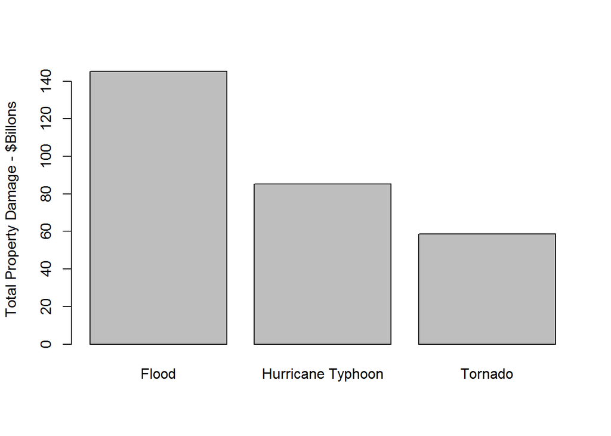

```r
par(mfrow = c(1,1))
barplot(PropDmgAmt[1:3]/1000000000, ylab = "Total Property Damage - $Billons")
```

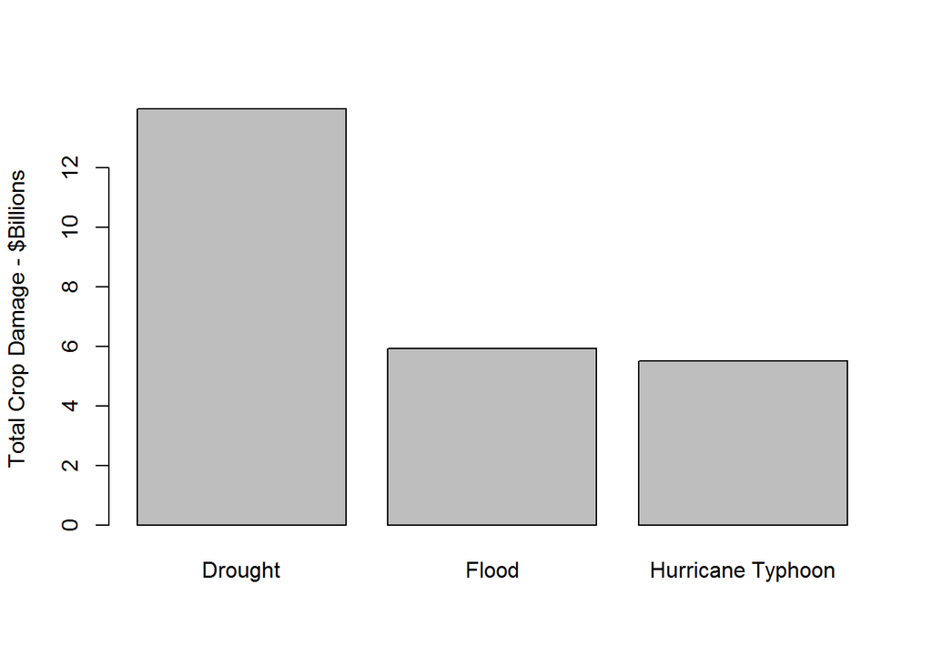

```r
barplot(CropDmgAmt[1:3]/1000000000, ylab = "Total Crop Damage - $Billions")
```